# Literate programming contoh implementasinya dalam pembelajaran sains

- Author: Dasapta Erwin Irawan[1], Cut Novianti Rachmi[2], dan Sandi Herho[1]
- Affiliasi:
  1. Institut Teknologi Bandung
  2. Universitas Padjadjaran
- Email: dasaptaerwin@outlook.co.id
- Description: This document is a manuscript for the SNIPS 2018 ITB
- Keywords: literate programming, reproducible research

# Abstrak

# Abstract

# Pendahuluan

# Sekilas tentang literate programming

*Literate programming* (LP) dikenalkan oleh David Knuth. Bila dilacak dokumentasinya, maka ide ini pertama kali terbit sebagai makalah dalam jurnal ([Knuth, 1984](https://academic.oup.com/comjnl/article/27/2/97/343244)). Dalam dokumen itu, Knuth menyampaikan bahwa dunia pemrograman secara umum memerlukan suatu cara agar kode program yang sama dapat diulang oleh orang lain, sekarang konsep ini diberi nama *reproducible research*/RR (riset yang dapat diulang). Definisi dari RR dijelaskan dengan sangat baik oleh [ROpensci (2018)](http://ropensci.github.io/reproducibility-guide/sections/introduction/), yakni suatu upaya yang bertujuan agar pihak lain dapat mengulang setiap prosedur riset yang telah kita lakukan. Tidak hanya mengulang, tapi lebih jauh lagi, yakni dapat menggunakan ulang (*reuse*) dan memodifikasinya untuk keperluan lain (*remix*), atau bahkan mengoreksi alur yang kita buat (*contribute*) ([Peng, 2011](http://science.sciencemag.org/content/334/6060/1226)),([Sandve et al., 2013](https://www.ncbi.nlm.nih.gov/pubmed/24204232)).

# Metode

Dalam artikel ini kami akan menggunakan Jupyter Notebook (JN) sebuah aplikasi LP yang awalnya dikembangkan untuk Bahasa Pemrograman Python. Bagi pengguna Linux dan MacOSX, [Python](https://www.python.org/) adalah bawaan sistem operasi (SO), walaupun demikian, direkomendasikan untuk memeriksa versi Pythonnya dan memperbaruinya. JN berjalan dengan baik pada Python versi 2.7 atau 3.x. Bagi pengguna SO Windows, Anda perlu menginstalasi Python secara terpisah. Distribusi [Continuum Anaconda](https://anaconda.org/) adalah yang kami rekomendasikan untuk SO Linux, MacOSX, dan Windows karena kemudahannya dan kelengkapan panduan instalasinya. Seluruh hasil komputasi di sini tidak dilakukan secara salin-tempel (*copy-paste*) tetapi adalah hasil dari proses pengkodean (*coding*).

Kemudian kami akan membuat analisis statistik sederhana berdasarkan data terbuka kualitas air sumur di Semarang dari penelitian sebelumnya ([Triadi et al. 2016](https://doi.pangaea.de/10.1594/PANGAEA.862987)). Data, kode, dan narasi akan dikombinasikan ke dalam artikel ini secara langsung untuk mendemonstrasikan LP. Analisis statistik yang dilakukan: mendeskripsikan data, membuat histogram untuk melihat distribusi data, dan membuat beberapa grafik x-y untuk melihat beberapa korelasi yang mungkin muncul diantara parameter yang diukur.

# Contoh aplikasi dalam analisis statistik sederhana

## Deskripsi data

Kami akan mendeskripsikan data menggunakan fungsi dalam *library* `Pandas`. Langkah-langkahnya adalah: (1) memuat `Pandas` ke memori, (2) membuka data menggunakan fungsi `pd.read_csv` dan menyimpannya sebagai `dataframe` bernama `data`, (3) kemudian menampilkannya sebagai tabel (10 baris pertama). Lihat Tabel 1 di bawah ini.

```python
import pandas as pd # langkah 1
data = pd.read_csv('data.csv', sep='\t') # langkah 2
print('Tabel 1 Data')
data.head(n=10) # langkah 3
```

```
Tabel 1 Data
```

|  | Event | Area | date_time | lat | long | utm_east | utm_north | utm_zone | depth | wl | ... | k | ca | mg | na | so4 | cl | hco3 | balance | aquifer | facies |
| --- | --- | --- | --- | --- | --- | --- | --- | --- | --- | --- | --- | --- | --- | --- | --- | --- | --- | --- | --- | --- | --- |
| 0 | SB_185 | PT. Ny.Meneer-1 | 1992 | -6.95854 | 110.45625 | 439936 | 9230800 | 49M | 96.0 | 23.37 | ... | 6.5 | 10.0 | 6.0 | 120.0 | 92.5 | 35.7 | 222.0 | -1.5 | Garang | sodium bicarbonate |
| 1 | SB_273 | PT. INAN | 1992 | -6.98295 | 110.44322 | 438500 | 9228100 | 49M | 94.0 | 14.40 | ... | 5.0 | 8.7 | 8.0 | 150.0 | 65.5 | 136.4 | 171.4 | -1.7 | Quaternary marine | sodium chloride |
| 2 | SB_283 | Obs. SD Kuningan | 1992 | -6.96437 | 110.41608 | 435500 | 9230150 | 49M | 150.0 | 15.25 | ... | 10.0 | 3.7 | 29.0 | 148.0 | 71.7 | 37.2 | 379.1 | 2.8 | Garang | sodium bicarbonate |
| 3 | SB_271 | PT. Sango Keramik | 1992 | -6.98006 | 110.31332 | 424150 | 9228400 | 49M | 65.0 | 31.49 | ... | 6.0 | 41.2 | 12.0 | 30.0 | 10.9 | 13.9 | 261.7 | -4.3 | Damar | calcium bicarbonate |
| 4 | SB_270 | Dolog Mangkang | 1992 | -6.97099 | 110.29341 | 421950 | 9229400 | 49M | NaN | 19.80 | ... | 9.0 | 45.0 | 16.4 | 50.0 | 38.3 | 57.0 | 231.9 | -1.6 | Damar | calcium bicarbonate |
| 5 | SB_278 | Hotel Santika | 1992 | -6.99333 | 110.42918 | 436950 | 9226950 | 49M | 86.0 | 7.86 | ... | 10.0 | 53.7 | 29.4 | 160.0 | 14.9 | 224.0 | 355.9 | -0.6 | Quaternary marine | sodium bicarbonate |
| 6 | SB_325 | PT Wahyu Utomo | 1992 | -6.99323 | 110.34770 | 427950 | 9226950 | 49M | 76.0 | 44.60 | ... | 6.0 | 46.2 | 13.6 | 50.0 | 70.4 | 12.4 | 268.4 | -3.8 | Damar | calcium bicarbonate |
| 7 | SB_190 | PT. Gentong Gotri | 1992 | -6.98338 | 110.42874 | 436900 | 9228050 | 49M | NaN | 22.10 | ... | 15.0 | 36.2 | 34.6 | 134.0 | 15.5 | 173.6 | 301.3 | 3.4 | Quaternary marine | sodium bicarbonate |
| 8 | SB_256 | Tambakharjo, Tugu | 1992 | -6.97832 | 110.36447 | 429800 | 9228600 | 49M | NaN | 4.64 | ... | 19.0 | 10.5 | 60.0 | 320.0 | 22.0 | 664.0 | 117.2 | -3.0 | Quaternary marine | sodium chloride |
| 9 | SB_206 | Tambak Udang, Mangkang | 1992 | -6.95020 | 110.30385 | 423100 | 9231700 | 49M | 80.0 | 11.57 | ... | 12.0 | 2.5 | 9.0 | 164.0 | 123.5 | 111.6 | 169.6 | -1.2 | Quaternary marine | sodium chloride |

10 rows × 25 columns

Kemudian kita akan membuat grafik histogram parameter zat padat terlarut (*total dissolved solids*, kolom `tds`), kandungan klor (kolom `cl`), kalsium (kolom `ca`) dan elevasi sumur (kolom `elevation`). Untuk membuat grafik, kami menggunakan *library* `Seaborn` dan memuatnya ke memori dengan nama `sns`.

[output not shown]

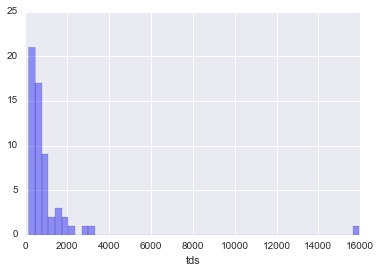

```python
%matplotlib inline # perintah untuk memuat grafik langsung ke dalam notebook ini (inline plotting)
import numpy as np # memuat library numpy (numeric python) sebagai np
import seaborn as sns # memuat library seaborn sebagai sns
sns.distplot(data['tds'], kde=False, color='b')
print('Gambar 1 Plot histogram TDS (ppm)')
```

[output not shown]

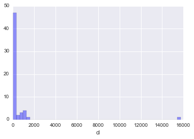

```python
sns.distplot(data['cl'], kde=False, color='b')
print('Gambar 2 Plot histogram klor (ppm)')
```

[output not shown]

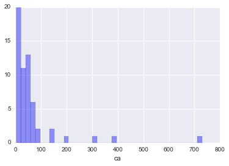

```python
sns.distplot(data['ca'], kde=False, color='b')
print('Gambar 2 Plot histogram kalsium (ppm)')
```

[output not shown]

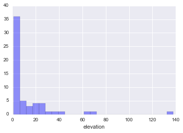

```python
sns.distplot(data['elevation'], kde=False, color='b')
print('Gambar 3 Plot histogram elevasi posisi sumur (ppm)')
```

## Korelasi

Selanjutnya kami akan mencoba membuat tabel matriks korelasi. Sebelumnya kolom dalam `dataframe` yang berisi teks (string) perlu dikeluarkan dan disimpan sebagai `dataframe` baru bernama `d` dengan fungsi `dataframe.loc()` (lihat Tabel 2). Kemudian kami buat tabel berikutnya berisi beberapa ukuran statistik dasarnya menggunakan fungsi `dataframe.describe()`(lihat Tabel 3). Pada baris berikutnya, kami menayangkan matriks korelasi dengan fungsi `dataframe.corr()` (lihat Tabel 4).

```python
d = data.loc[:,'tds':'hco3']
d.head(n=10)
print('Tabel 2 Dataframe yang baru')
```

[output not shown]

```python
print('Tabel 3 Statistik dasar dataframe d' )
d.describe()
```

```
Tabel 3 Statistik dasar dataframe d
```

|  | tds | ph | ec | k | ca | mg | na | so4 | cl | hco3 |
| --- | --- | --- | --- | --- | --- | --- | --- | --- | --- | --- |
| count | 58.000000 | 58.000000 | 58.000000 | 58.000000 | 58.000000 | 58.000000 | 58.000000 | 58.000000 | 58.000000 | 58.000000 |
| mean | 1040.517241 | 7.453103 | 1561.189655 | 10.650000 | 63.577759 | 53.807241 | 299.018966 | 44.218966 | 496.865517 | 336.675862 |
| std | 2080.304636 | 0.735015 | 3116.152286 | 8.477343 | 111.128017 | 236.734501 | 934.950288 | 35.416962 | 2067.984323 | 286.405291 |
| min | 152.000000 | 6.420000 | 226.000000 | 1.500000 | 2.500000 | 0.500000 | 22.000000 | 6.400000 | 11.200000 | 78.800000 |
| 25% | 425.000000 | 7.142500 | 672.250000 | 6.100000 | 17.600000 | 7.125000 | 56.750000 | 16.775000 | 40.175000 | 239.050000 |
| 50% | 556.000000 | 7.305000 | 875.000000 | 8.250000 | 37.000000 | 15.550000 | 140.000000 | 36.950000 | 80.550000 | 276.750000 |
| 75% | 934.000000 | 7.670000 | 1347.750000 | 11.900000 | 54.300000 | 28.425000 | 243.000000 | 64.275000 | 221.850000 | 368.250000 |
| max | 15947.000000 | 11.600000 | 23900.000000 | 49.000000 | 730.400000 | 1811.700000 | 7200.000000 | 166.100000 | 15752.800000 | 2262.900000 |

```python
print('Tabel 4 Matriks korelasi dataframe d' )
d.corr()
```

|  | tds | ph | ec | k | ca | mg | na | so4 | cl | hco3 |
| --- | --- | --- | --- | --- | --- | --- | --- | --- | --- | --- |
| tds | 1.000000 | -0.020906 | 0.999770 | 0.268030 | 0.865850 | 0.978942 | 0.987034 | 0.026610 | 0.989866 | 0.890621 |
| ph | -0.020906 | 1.000000 | -0.021676 | -0.129942 | -0.112700 | -0.043160 | -0.001383 | 0.034096 | -0.029729 | 0.018041 |
| ec | 0.999770 | -0.021676 | 1.000000 | 0.269267 | 0.865724 | 0.979582 | 0.986649 | 0.022284 | 0.989664 | 0.892535 |
| k | 0.268030 | -0.129942 | 0.269267 | 1.000000 | 0.370504 | 0.161970 | 0.178290 | -0.054717 | 0.195601 | 0.227762 |
| ca | 0.865850 | -0.112700 | 0.865724 | 0.370504 | 1.000000 | 0.828171 | 0.830466 | -0.052327 | 0.851196 | 0.840162 |
| mg | 0.978942 | -0.043160 | 0.979582 | 0.161970 | 0.828171 | 1.000000 | 0.991248 | -0.028558 | 0.994212 | 0.906087 |
| na | 0.987034 | -0.001383 | 0.986649 | 0.178290 | 0.830466 | 0.991248 | 1.000000 | 0.012856 | 0.997764 | 0.897149 |
| so4 | 0.026610 | 0.034096 | 0.022284 | -0.054717 | -0.052327 | -0.028558 | 0.012856 | 1.000000 | -0.013346 | -0.018374 |
| cl | 0.989866 | -0.029729 | 0.989664 | 0.195601 | 0.851196 | 0.994212 | 0.997764 | -0.013346 | 1.000000 | 0.892814 |
| hco3 | 0.890621 | 0.018041 | 0.892535 | 0.227762 | 0.840162 | 0.906087 | 0.897149 | -0.018374 | 0.892814 | 1.000000 |

Dari tabel 4 di atas, dapat Anda lihat bahwa nilai TDS memiliki korelasi yang kuat dengan kandungan Ca, Mg, Na, Cl, dan HCO3, tapi memiliki korelasi lemah dengan K. Untuk memperlihatkan korelasi tersebut, kami buatkan grafik x-y antara TDS dengan Mg dan TDS dengan K (lihat Gambar 4 dan 5 berikut ini). Kedua plot menggunakan fungsi `sns.regplot()` dengan beberapa kode tambahan untuk pengaturan penamaan sumbu.

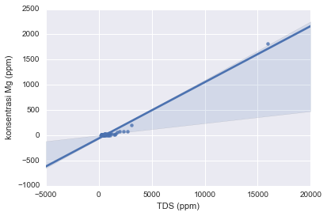

```
Gambar 4 Plot TDS terhadap Mg
```

```python
ax = sns.regplot(x='tds', y='mg', data=d)
ax.set_xlabel("TDS (ppm)")
ax.set_ylabel("konsentrasi Mg (ppm)")
plt.show()
print('Gambar 4 Plot TDS terhadap Mg')
```

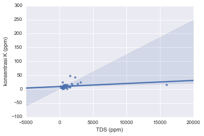

```
Gambar 5 Plot TDS terhadap K
```

```python
ax = sns.regplot(x='tds', y='k', data=d)
ax.set_xlabel("TDS (ppm)")
ax.set_ylabel("konsentrasi K (ppm)")
plt.show()
print('Gambar 5 Plot TDS terhadap K')
```

# Beberapa catatan

Jika diperhatikan demo di atas, dapat kita lihat bahwa tahapan-tahapan dalam analisis statistik dapat dijelaskan secara naratif, bukan dengan komentar pada baris kode yang pendek-pendek. Biasanya kita memberikan komentar atau penjelasan dengan diawali karakter `#`. Dokumen JN ini, pada waktunya, dapat diekspor sebagai dokumen berformat PDF atau HTML hanya dengan memilih opsi pada menu `File` di atas. Hasilnya adalah satu file PDF atau HTML yang siap tayang berisi perintah kode, luarannya berupa tabel atau grafik, serta penjelasannya. Bahkan makalah ini pun dikonsep secara langsung dalam JN.

Dengan menggunakan JN ini, proses belajar mengajar dapat menjadi lebih mudah. Pengajar hanya perlu memberikan file JN ini, disertai data mentahnya. Para siswa akan menyalin file-file yang diperlukan ke dalam folder kerjanya, maka mereka akan dapat menjalankan perintah dan menghasilkan luaran yang persis sama dengan tayangan pengajar. Piranti lunak yang diperlukanpun sangat fungsional, serta seluruhnya gratis dan *open source*, sehingga dapat menghemat biaya penyelenggaraan pendidikan.

# Daftar pustaka

1. D. E. Knuth (1984) Literate Programming, The Computer Journal, Volume 27, Issue 2, Pages 97–111, url: https://doi.org/10.1093/comjnl/27.2.97.
2. ROpensci (2018) Reproducibility guide, ROpensci blog, url: http://ropensci.github.io/reproducibility-guide/sections/introduction/.
3. Peng, R.D. (2011) Reproducible Research in Computational Science, Sciencemag blog, url: http://science.sciencemag.org/content/334/6060/1226.
4. Sandve GK, Nekrutenko A, Taylor J, Hovig E. (2013) Ten simple rules for reproducible computational research, PLOS Computational Biology, url:https://www.ncbi.nlm.nih.gov/pubmed/24204232.
5. Kalelioglu, F (2015) A new way of teaching programming skills to K-12 students, Computers in Human Behavior, Volume 52, November 2015, Pages 200-210, url: https://www.sciencedirect.com/science/article/pii/S0747563215004288.
6. Putranto, Thomas Triadi; Rüde, Thomas; Irawan, Dasapta Erwin (2016): Hydrochemical properties of groundwater samples in Semarang area, Java Island, Indonesia (1992, 1993, 2003, 2006, and 2007). PANGAEA, https://doi.org/10.1594/PANGAEA.862987.